# Statistical Inference Course Project

ETaylor

3 March 2017

## Overview

This project is reported in two parts. Part 1 is a simulation excercise to investigate the exponential distribution in R and compare it with the Central Limit Theorem. Part 2 is demonstrates basic inferential data analysis by exploring the ToothGrowth data in the R datasets package.

## Part 1: Simulation Exercise

The exponential distribution can be simulated in R with rexp(n, lambda) where lambda is the rate parameter. The mean of exponential distribution is 1/lambda and the standard deviation is also 1/lambda and lambda = 0.2 for all of the simulations. The distribution of averages of 40 exponentials will be investigated over 1000 simulations.

```r
lambda<-0.2
n<-40
mn_rexp<-NULL
for (i in 1:1000) mn_rexp<-c(mn_rexp, mean(rexp(n,lambda)))
```

### Sample Mean versus Theoretical Mean

The theoretical mean is 5 (as given by 1/lambda). The histogram illustrates the distibution of averages of 40 exponentials and highlights the sample mean with a vertical line. It is 4.99, which is very close to the theoretical mean.

For a large sample distribution of sample means of a collection of iid observations, this is what we would expect. The law of large numbers tells us that the average converges to what it is estimating, the population (or theoretical) mean.va

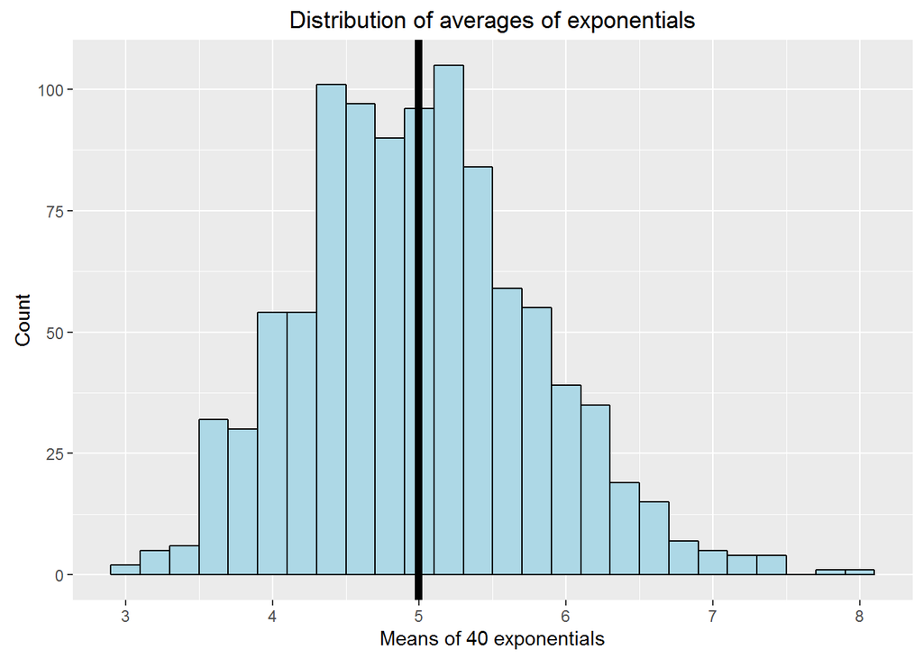

### Sample Variance versus Theoretical Variance

```r
for (i in 1:1000)  sum_dif = sum((mn_rexp-mean(mn_rexp))^2)
var<-sum_dif/999
#or
var(mn_rexp)
```

```
## [1] 0.6274476
```

```r
vardif<-(abs( (1/lambda)^2/n - var(mn_rexp))/(1/lambda)^2/n )*100
```

### Distribution

The following density histogram compares the distribution of sample means (density plot in black) with the actual normal distribution (red).

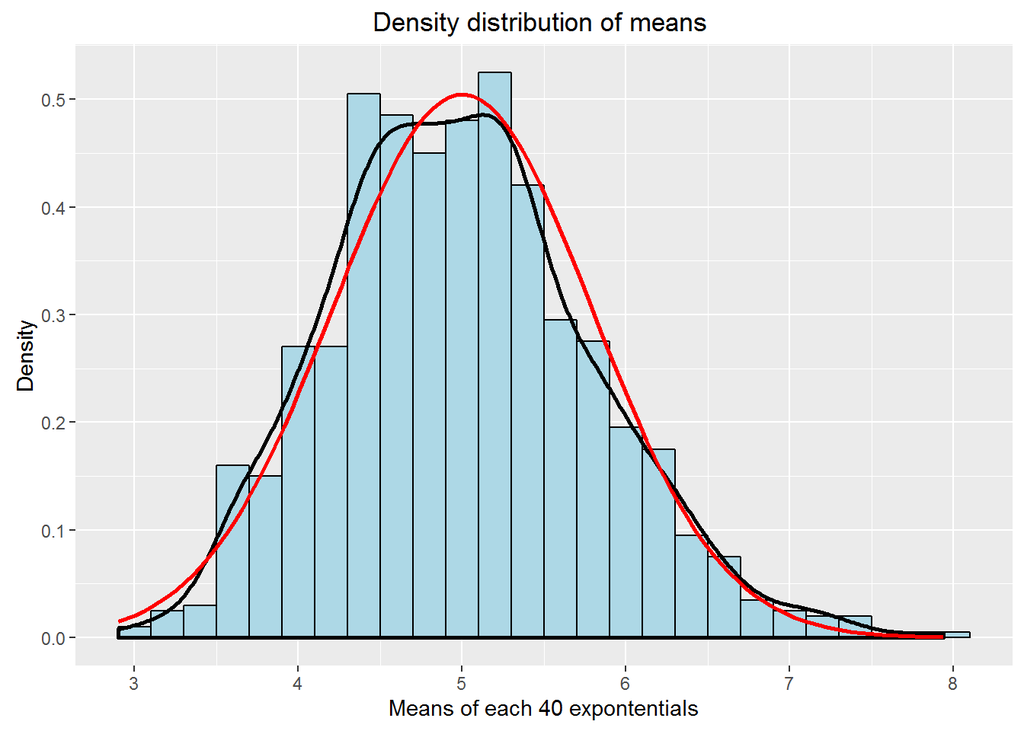

It can be seen that the distribution of sample means is approximately normal. This is again expected from the Central Limit Theorem (CLT), which states that the distribution of averages of iid variables becomes that of a standard normal as the sample size increases. We would therefore expect our simulated results to continue to converge with a normal distribution as the number of simulations increased.